# dplyr_homework

Load in the dataset and call it drinks_content, eyeball it by printing it out (first 5 rows, last 5 rows, and then all of the data) and find out the dimensions (number of rows/columns) and variable names.

```r
library(readr)
library(tidyverse)
starbucks_drinks <-
  read_csv("data/starbucks_drinkMenu_expanded.csv")
```

```r
head(starbucks_drinks, n = 5)
```

| Beverage_category | Beverage | Beverage_prep | Calories | Total Fat (g) | Trans Fat (g) | Saturated Fat (g) | Sodium (mg) | Total Carbohydrates (g) | Cholesterol (mg) | Dietary Fibre (g) | Sugars (g) | Protein (g) | Vitamin A (% DV) | Vitamin C (% DV) | Calcium (% DV) | Iron (% DV) | Caffeine (mg) |
| --- | --- | --- | --- | --- | --- | --- | --- | --- | --- | --- | --- | --- | --- | --- | --- | --- | --- |
| Coffee | Brewed Coffee | Short | 3 | 0.1 | 0.0 | 0 | 0 | 5 | 0 | 0 | 0 | 0.3 | 0% | 0% | 0% | 0% | 175 |
| Coffee | Brewed Coffee | Tall | 4 | 0.1 | 0.0 | 0 | 0 | 10 | 0 | 0 | 0 | 0.5 | 0% | 0% | 0% | 0% | 260 |
| Coffee | Brewed Coffee | Grande | 5 | 0.1 | 0.0 | 0 | 0 | 10 | 0 | 0 | 0 | 1.0 | 0% | 0% | 0% | 0% | 330 |
| Coffee | Brewed Coffee | Venti | 5 | 0.1 | 0.0 | 0 | 0 | 10 | 0 | 0 | 0 | 1.0 | 0% | 0% | 2% | 0% | 410 |
| Classic Espresso Drinks | Caffè Latte | Short Nonfat Milk | 70 | 0.1 | 0.1 | 0 | 5 | 75 | 10 | 0 | 9 | 6.0 | 10% | 0% | 20% | 0% | 75 |

```r
tail(starbucks_drinks, n = 5)
```

| Beverage_category | Beverage | Beverage_prep | Calories | Total Fat (g) | Trans Fat (g) | Saturated Fat (g) | Sodium (mg) | Total Carbohydrates (g) | Cholesterol (mg) | Dietary Fibre (g) | Sugars (g) | Protein (g) | Vitamin A (% DV) | Vitamin C (% DV) | Calcium (% DV) | Iron (% DV) | Caffeine (mg) |
| --- | --- | --- | --- | --- | --- | --- | --- | --- | --- | --- | --- | --- | --- | --- | --- | --- | --- |
| Frappuccino® Blended Crème | Strawberries & Crème (Without Whipped Cream) | Soymilk | 320 | 3 2 | 0.4 | 0.0 | 0 | 250 | 67 | 1 | 64 | 5 | 6% | 8% | 20% | 10% | 0 |
| Frappuccino® Blended Crème | Vanilla Bean (Without Whipped Cream) | Tall Nonfat Milk | 170 | 0.1 | 0.1 | 0.0 | 0 | 160 | 39 | 0 | 38 | 4 | 6% | 0% | 10% | 0% | 0 |
| Frappuccino® Blended Crème | Vanilla Bean (Without Whipped Cream) | Whole Milk | 200 | 3.5 | 2.0 | 0.1 | 10 | 160 | 39 | 0 | 38 | 3 | 6% | 0% | 10% | 0% | 0 |
| Frappuccino® Blended Crème | Vanilla Bean (Without Whipped Cream) | Soymilk | 180 | 1.5 | 0.2 | 0.0 | 0 | 160 | 37 | 1 | 35 | 3 | 4% | 0% | 10% | 6% | 0 |
| Frappuccino® Blended Crème | Vanilla Bean (Without Whipped Cream) | Grande Nonfat Milk | 240 | 0.1 | 0.1 | 0.0 | 5 | 230 | 56 | 0 | 55 | 5 | 8% | 0% | 15% | 0% | 0 |

```r
dim(starbucks_drinks)
```

```
[1] 242  18
```

```r
names(starbucks_drinks)
```

```
 [1] "Beverage_category"       "Beverage"                "Beverage_prep"
 [4] "Calories"                "Total Fat (g)"           "Trans Fat (g)"
 [7] "Saturated Fat (g)"       "Sodium (mg)"             "Total Carbohydrates (g)"
[10] "Cholesterol (mg)"        "Dietary Fibre (g)"       "Sugars (g)"
[13] "Protein (g)"             "Vitamin A (% DV)"        "Vitamin C (% DV)"
[16] "Calcium (% DV)"          "Iron (% DV)"             "Caffeine (mg)"
```

We’re going to be looking at the number of calories in each drink.

Calculate some quick summary statistics to check the mean, the variance, and the normality of this variable.

```r
summary(starbucks_drinks$Calories)
```

```
   Min. 1st Qu.  Median    Mean 3rd Qu.    Max.
    0.0   120.0   185.0   193.9   260.0   510.0
```

```r
var(starbucks_drinks$Calories)
```

```
[1] 10580.86
```

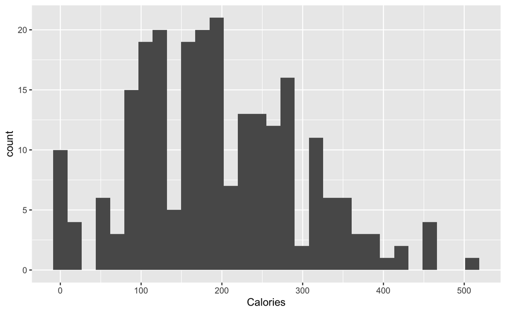

```r
starbucks_drinks %>%
  ggplot(aes(Calories)) +
  geom_histogram()
```

Check if you have any outliers in the Calories variable by creating a boxplot. Then get the actual values of any outliers you have. Finally remove the outliers and save the new tibble as drinks_content_nooutlier.

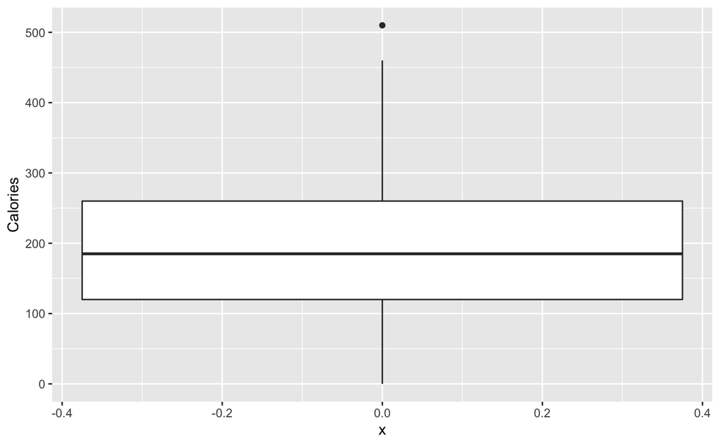

```r
starbucks_drinks %>%
  ggplot(aes(x = NULL, y = Calories)) +
  geom_boxplot()
```

```r
outliers <- boxplot(starbucks_drinks$Calories, plot = FALSE)$out
print(outliers)
```

```
[1] 510
```

```r
starbucks_drinks[which(starbucks_drinks$Calories %in% outliers), ]
```

| Beverage_category | Beverage | Beverage_prep | Calories | Total Fat (g) | Trans Fat (g) | Saturated Fat (g) | Sodium (mg) | Total Carbohydrates (g) | Cholesterol (mg) | Dietary Fibre (g) | Sugars (g) | Protein (g) | Vitamin A (% DV) | Vitamin C (% DV) | Calcium (% DV) | Iron (% DV) | Caffeine (mg) |
| --- | --- | --- | --- | --- | --- | --- | --- | --- | --- | --- | --- | --- | --- | --- | --- | --- | --- |
| Signature Espresso Drinks | White Chocolate Mocha (Without Whipped Cream) | 2% Milk | 510 | 15 | 9 | 0.2 | 35 | 330 | 77 | 0 | 74 | 19 | 20% | 4% | 60% | 2% | 150 |

Remove the outliers and save the new tibble as drinks_content_nooutlier

```r
drinks_content_nooutlier <- starbucks_drinks[-which(starbucks_drinks$Calories %in% outliers), ]
```

Select the variables beverage_category, beverage, beverage prep and calories from the data (drinks_content_nooutlier), and assign it to a new tibble called drinks. Since we are interested in the calorie content, check if there are any NA values in the data, and drop them if there are.

```r
drinks <-drinks_content_nooutlier %>%
  select(Beverage_category, Beverage, Beverage_prep, Calories)
```

```r
is.na(drinks)
```

[output not shown]

[output cut: 227 more lines]

Filter the data so we only take “classic espresso drinks”, and save this in a new tibble called espresso_drinks.

```r
espresso_drinks <- drinks %>%
  filter(Beverage_category == "Classic Espresso Drinks")
```

Create a new tibble called drink_calories which contains a variable called calorie_diff. calorie_diff should store the difference between 135 calories (135 calories = 10 cubes of sugar!) and the calories in each drink. (hint: you’ll want to subtract the calories from 135 to see which drink have more or less than 10 cups of sugar).

```r
drink_calories <- espresso_drinks %>%
  mutate(calorie_diff = 135 - Calories)
```

Create a new tibble called drinks_grouped where you group your data by the type of beverage prep. Then summarise the mean calories in each drink (by group) in a variable called mean_cal, and save it to drinks_summary. Finally arrange this summary data in descending order of mean calories.

```r
drinks_grouped <- drink_calories %>%
  group_by(Beverage_prep) %>%
  summarise(mean_cal = mean(Calories))
```

Hopefully you can see by now how much hassle it can be to constantly keep creating tibbles to store all your data.

Finish up by using the %>% operator to put all the answers you’ve got from questions 4-7 into one pipe. You don’t need to include the check for NA values in this, as you’d typically check that before you start doing any analysis.

```r
drinks %>%
  filter(Beverage_category == "Classic Espresso Drinks") %>%
  mutate(calorie_diff = 135 - Calories) %>%
  group_by(Beverage_prep) %>%
  summarise(mean_cal = mean(Calories))
```

| Beverage_prep | mean_cal |
| --- | --- |
| 2% Milk | 184.375 |
| Doppio | 10.000 |
| Grande | 15.000 |
| Grande Nonfat Milk | 150.000 |
| Short | 5.000 |
| Short Nonfat Milk | 78.000 |
| Solo | 5.000 |
| Soymilk | 151.250 |
| Tall | 10.000 |
| Tall Nonfat Milk | 116.000 |

[output cut: 2 more lines]

```r
most_calories <- drink_calories %>%
  filter(min_rank(desc(Calories)) == 1) %>%
  select(Beverage, Calories)

most_calories
```

| Beverage | Calories |
| --- | --- |
| Caffè Mocha (Without Whipped Cream) | 340 |

For each drink in the drinks_grouped data, find all drinks which more calories than the average drink. Save this in a new tibble called above_average_calories.

```r
above_average_calories <- drinks_grouped %>%
  mutate(avg_of_group = mean(mean_cal)) %>%
  filter(mean_cal > avg_of_group)

above_average_calories
```

| Beverage_prep | mean_cal | avg_of_group |
| --- | --- | --- |
| 2% Milk | 184.375 | 78.63542 |
| Grande Nonfat Milk | 150.000 | 78.63542 |
| Soymilk | 151.250 | 78.63542 |
| Tall Nonfat Milk | 116.000 | 78.63542 |
| Venti Nonfat Milk | 194.000 | 78.63542 |

Within each drink group, rank each beverage by the number of calories. Save this ranking in a new column called ranking. Save the new output in a new tibble called drinks_ranked.

```r
ranking <- drinks_grouped %>%
  arrange(desc(mean_cal)) %>%
  filter(min_rank(desc(mean_cal)) >= 1)

ranking
```

| Beverage_prep | mean_cal |
| --- | --- |
| Venti Nonfat Milk | 194.000 |
| 2% Milk | 184.375 |
| Soymilk | 151.250 |
| Grande Nonfat Milk | 150.000 |
| Tall Nonfat Milk | 116.000 |
| Short Nonfat Milk | 78.000 |
| Venti | 25.000 |
| Grande | 15.000 |
| Doppio | 10.000 |
| Tall | 10.000 |

[output cut: 2 more lines]

```r
NA
```

Using the drinks_grouped data, apply the cume_dist function to get the top 25% of Calorie drinks within each group. Save this in a new tibble called drinks_distribution.

```r
drinks_distribution <- drinks_grouped %>%
  arrange(desc(mean_cal)) %>%
  filter(cume_dist(desc(mean_cal)) < 0.25)

drinks_distribution
```

| Beverage_prep | mean_cal |
| --- | --- |
| Venti Nonfat Milk | 194.000 |
| 2% Milk | 184.375 |